# Презентация по лабораторной работе No7

Операционные системы

Нджову Н.

Российский университет дружбы народов, Москва, Россия

20 марта 2024

## Цель работы

Ознакомление с файловой системой Linux, её структурой, именами и содержанием каталогов. Приобретение практических навыков по применению команд для работы с файлами и каталогами, по управлению процессами (и работами), по проверке использования диска и обслуживанию файловой системы.

## Задание

1. Выполнить все примеры из лабораторной работы
2. Выполнить команды по копирование,создание и перемещение файлов и каталогов
3. Определить опции команды chmod
4. Изменить права доступа к файлам
5. Прочитать документацию о командах mount,fsck,mkfs,kill

## 1. Выполнить все примеры из лабораторной работы

Я создаю новый файл abc1 и копирую его в файл april и в файл may.Потом я проверяю, что все команды выполнены правлино(рис.1)

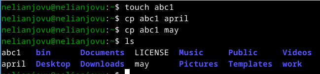

создание и копирование файла

## 1. Выполнить все примеры из лабораторной работы

Я создаю новую папку monthly, я копирую файл april и may в только созданную папку и проверяю если это сделаны правилно(рис.2)

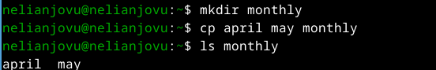

создание каталога и копирование файла в каталог

## 1. Выполнить все примеры из лабораторной работы

Я копирую файл monthly/may в файл с именем june(рис.3)

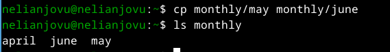

копирование файла

## 1. Выполнить все примеры из лабораторной работы

Я создаю новый каталог monthly.00 и копирую каталог monthly в каталог monthly.00(рис.4)

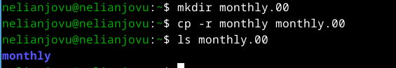

создание и копирование каталога

## 1. Выполнить все примеры из лабораторной работы

Я копирую каталог monthly.00 в каталоге /tmp(рис.5)

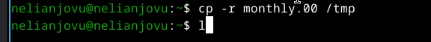

копирование каталога

## 1. Выполнить все примеры из лабораторной работы

Я переименовываю файл april в july(рис.6)

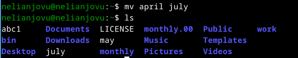

переименование файла

## 1. Выполнить все примеры из лабораторной работы

Я перемещаю файл july в каталог monthly.00(рис.7)

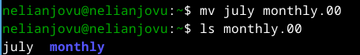

перемещение файла

## 1. Выполнить все примеры из лабораторной работы

Я переименовываю каталог monthly.00 в monthly.01 и создаю новый каталог reports(рис.8)

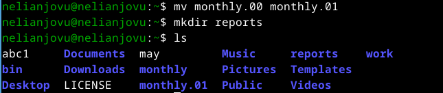

переименование каталога

## 1. Выполнить все примеры из лабораторной работы

Я перемещаю каталог monthly.01 в каталог reports

Я переименовывю каталог report/monthly.01 в report/monthly(рис.9)

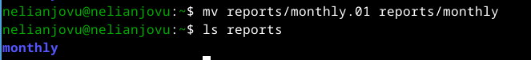

переименование каталога

## 1. Выполнить все примеры из лабораторной работы

Я проверяю права у файла may, изменяю права доступа, добавляя создателю можно выполнять файл(рис.10)

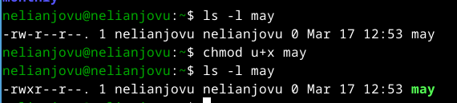

изменение правы доступы

## 1. Выполнить все примеры из лабораторной работы

Я лишаю владельца файла ~/may права на выполнение(рис.11)

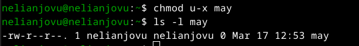

изменение правы доступы

## 1. Выполнить все примеры из лабораторной работы

Я меняю права доступа к каталогу monthly, группы и другие пользователи не смогу его прочитать(рис.12)

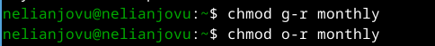

изменение правы доступы

Я меняю права доступа к файлу abc1, группы могут писать в этом файле

## 2. Выполнить команды по копирование,создание и перемещение файлов и каталогов

Я копирую файл /usr/include/sys/io.h в домашний каталог и назову его equipment(рис.13)

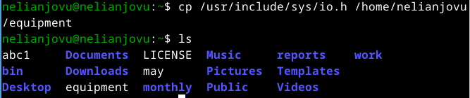

копирование и переименование файла

## 2. Выполнить команды по копирование,создание и перемещение файлов и каталогов

Я создаю новый каталог в домашнем каталоге ~/ski.plases

Я перемещаю файл equipment в каталог ~/ski.plases(рис.14)

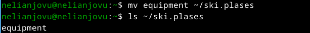

перемещение файла

## 2. Выполнить команды по копирование,создание и перемещение файлов и каталогов

Я переименовываю файл ~/ski.plases/equipment в ~/ski.plases/equiplist

Я копирую файла abc1 в каталог ~/ski.plases, назову его equiplist2(рис.15)

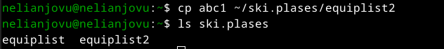

копирование файла

## 2. Выполнить команды по копирование,создание и перемещение файлов и каталогов

Я создаю каталог с именем equipment в каталоге ~/ski.plases

Я перемещаю файлы ~/ski.plases/equiplist и equiplist2 в каталог ~/ski.plases/equipment

Я создаю каталог ~/newdir, перемещаю его в каталог ~/ski.plases и назову его plans(рис.16)

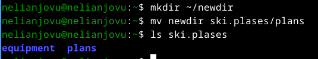

создание и перемещение каталога

## 3. Определить опции команды chmod

*Я определяю опции команды chmod, необходимые для того, чтобы присвоить перечисленным ниже файлам выделенные права доступа, считая, что в начале таких прав нет:*

Сначала я создаю каталог australia и добавляю права доступа drwxr–r–(рис.17)

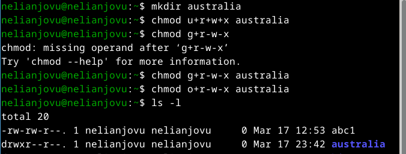

создание и изменение правы доступы australia

## 3. Определить опции команды chmod

Я создаю каталог play и добавляю права доступа drwx–x–x (рис.18)

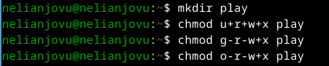

проверка

## 3. Определить опции команды chmod

Я создаю файл my_os и добавляю права доступа -r-xr–r–(рис.19)

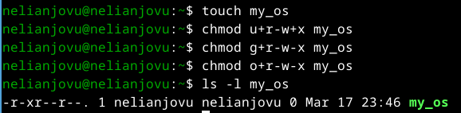

создание и изменение правы доступы my_os

## 3. Определить опции команды chmod

Я создаю файл feathers и добавляю права доступа -rw-rw-r–(рис.20)

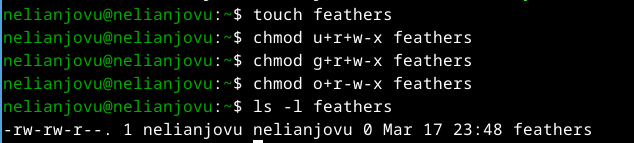

создание и изменение правы доступы feathers

## 4. Изменить права доступа к файлам

Я просморю содержимое в файл ~/.password-store(рис.21)

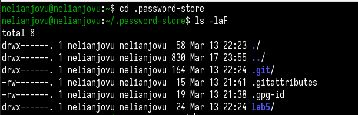

содержимое в файл ~/.password-store

## 4. Изменить права доступа к файлам

Я копирую файл ~/feathers в файл ~/file.old

Я перемещаю файл ~/file.old в каталог ~/play(рис.22)

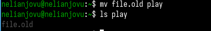

перемещение файла

## 4. Изменить права доступа к файлам

Я копирую каталог ~/play в каталог ~/fun

Я перемещаю каталог ~/fun в каталог ~/play и назову его games(рис.23)

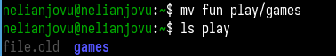

перемещение каталога

## 4. Изменить права доступа к файлам

Я меняю права доступа файла ~/feathers, владельца не могут читать файл

Когда я пытаюсь его открыть, он выдает ошибку, потому что у меня нет прав на чтение(рис.24)

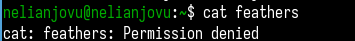

открытка файла

То же самое происходит, когда я пытаюсь скопировать его

Я даю владельцу файла ~/feathers право на чтение

## 4. Изменить права доступа к файлам

Я меняю права доступа каталог ~/play, владельца нет права выполнение

## 4. Изменить права доступа к файлам

Я меняю права доступа каталог ~/play, у владельцы есть права выполнение(рис.26)

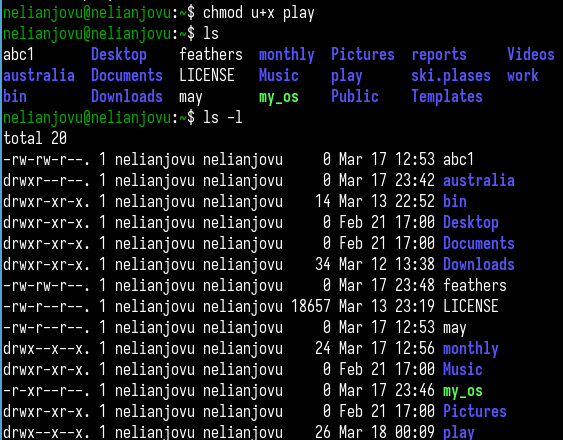

изменение правы доступы

## 5. Прочитать документацию о командах mount,fsck,mkfs,kill

mount - это утилита командой строки в UNIX-подобных операционных системых. Она используетсядля монтирования файловых систем

fsck(проверка файловой системы) - это утилита командой строки, которая позволяет выполнять проверку согласованности и интерактивное исправление в одной или нескольких файловых системах Linux. Она использует программы, специфичные для типа проверяемой файловой системы

## 5. Прочитать документацию о командах mount,fsck,mkfs,kill

Команд kill отправляет указанный сигнал указанному процессу. Если сигнал не указан, отправляется сигнал SIGTERM.Сигнал SIGTERM завершает работу только теч процессов, которые не обрабатывают его поступление. Для других процессов может потребоваться отправить сигнал SIGKILL, поскольку этот сигнал невозможно перехватить

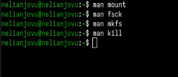

kill

## Выводы

При выполнении данной лабораторной работы я ознакомилась с файловой системой Linux, её структурой, именами и содержанием каталогов. Приобрела практические навыки по применению команд для работы с файлами и каталогами, по управлению процессами (и работами), по проверке использования диска и обслуживанию файловой системы